# DAT320: Compulsory assignment 2

2022-10-30

# Exrercise 1

## a)

(Univariate forecasting using Exponential Smoothing & ARIMA) The dataset MeatConsumption describes the yearly meat consumption in Norway between 1990 and 2019. In specific, the meat types pig, poultry, beef, and sheep are provided. Data are given in thousand tonnes of carcass weight. Material provided: • MeatConsumption.csv: dataset Tasks: (a) Load the dataset and perform an exploratory analysis of the meat consumption for each type of meat (missing values, distribution plots, ACF & PACF, KPSS test, etc.). Are the time series stationary? Which ARIMA parameters would you suggest based on the KPSS test and ACF / PACF?

Reading the data

```r
library(dplyr)
```

```r
library(tidyr)
library(ggplot2)
library(corrplot)
library(tseries)
library(forecast)
library(ggfortify)
library(Metrics)
library(naivebayes)
library(tidyverse)
library(TSstudio)
library(datasets)
library(imputeTS)
library(bestNormalize)
data <- read.csv("data//meat_consumption.csv",
                 header = TRUE, sep = ",")
```

Eploring for missing values and ploting the data based on different types of meats.

```r
# Number of null values
na_values = which(is.na(data))
length(na_values)
```

```
## [1] 0
```

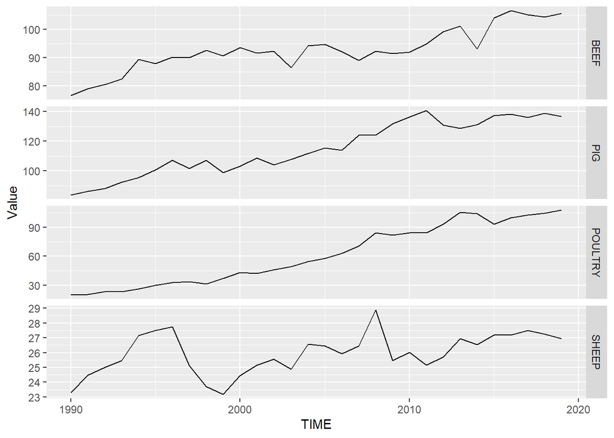

```r
#Plot the data on the basis of subject
ggplot(data ,aes(x = TIME , y = Value, group = SUBJECT)) +
  geom_line() + facet_grid(SUBJECT~., scale = "free_y")
```

Making correlation plot

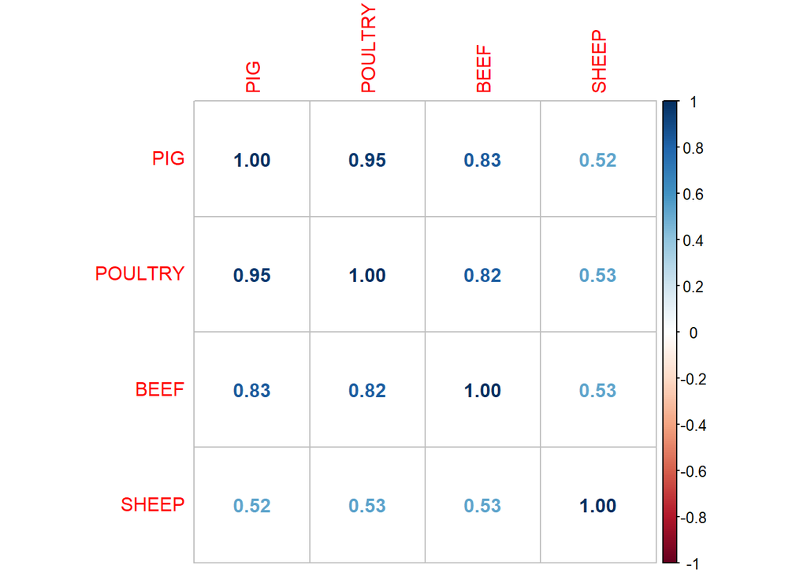

```r
data %>%
  pivot_wider(names_from = SUBJECT,
              values_from = Value)  %>%
   select(-LOCATION) %>%
  select(-MEASURE)%>%
  select(-TIME) %>%
  cor(use =  "pairwise.complete.obs") %>%
  corrplot(method = 'number')
```

```r
data1 <- data %>%
  pivot_wider(names_from = SUBJECT,
              values_from = Value) %>%
  select(-LOCATION) %>%
  select(-MEASURE)%>%
  select(-TIME)
```

KPSS test on the data

```r
data1 <- ts(data1, start = c(1990) , frequency=1)
class(data1)
```

```
## [1] "mts"    "ts"     "matrix"
```

```r
colnames(data1)
```

```
## [1] "PIG"     "POULTRY" "BEEF"    "SHEEP"
```

```r
kpss.test(data1[,"PIG"])
```

```
##
##  KPSS Test for Level Stationarity
##
## data:  data1[, "PIG"]
## KPSS Level = 1.0517, Truncation lag parameter = 2, p-value = 0.01
```

```r
kpss.test(data1[,"POULTRY"])
```

```
##
##  KPSS Test for Level Stationarity
##
## data:  data1[, "POULTRY"]
## KPSS Level = 1.0784, Truncation lag parameter = 2, p-value = 0.01
```

```r
kpss.test(data1[,"BEEF"])
```

```
##
##  KPSS Test for Level Stationarity
##
## data:  data1[, "BEEF"]
## KPSS Level = 0.91814, Truncation lag parameter = 2, p-value = 0.01
```

```r
kpss.test(data1[,"SHEEP"])
```

```
##
##  KPSS Test for Level Stationarity
##
## data:  data1[, "SHEEP"]
## KPSS Level = 0.42203, Truncation lag parameter = 2, p-value = 0.06766
```

Based on KPSS test sheep data has not trend but other types of meats have trend behavior over the time period.

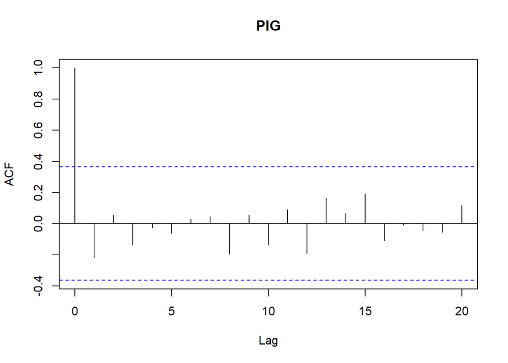

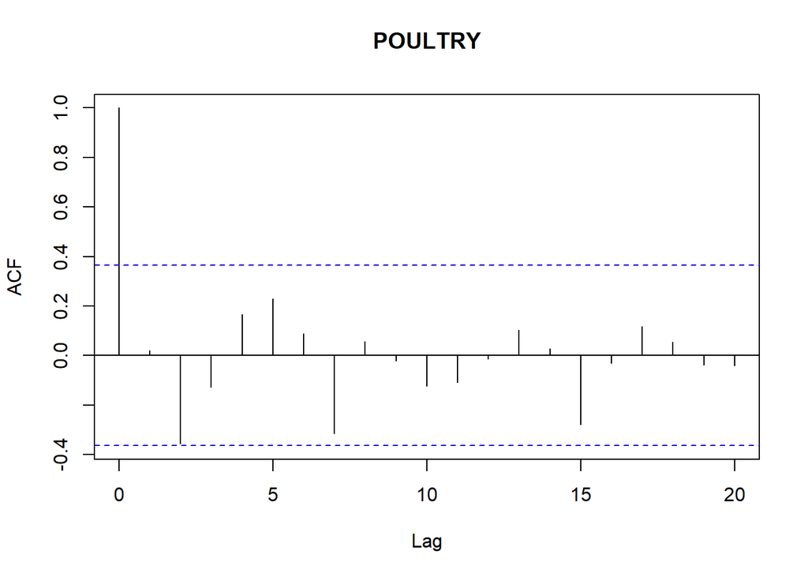

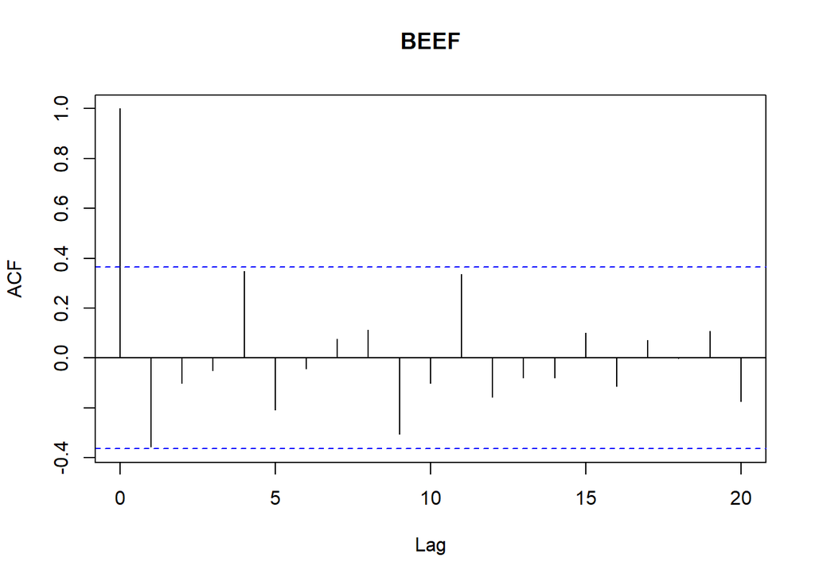

```r
# removing the trend of different types of meats except to SHEEP

beef.dif <- diff(data1[,"BEEF"])
pig.dif <- diff(data1[,"PIG"])
poultry.dif <- diff(data1[,"POULTRY"])


# ACF
n <- length(4)
for(i in 1:3){
  acf(diff(data1[,i]), main = colnames(data1)[i], lag.max = 20)
}
```

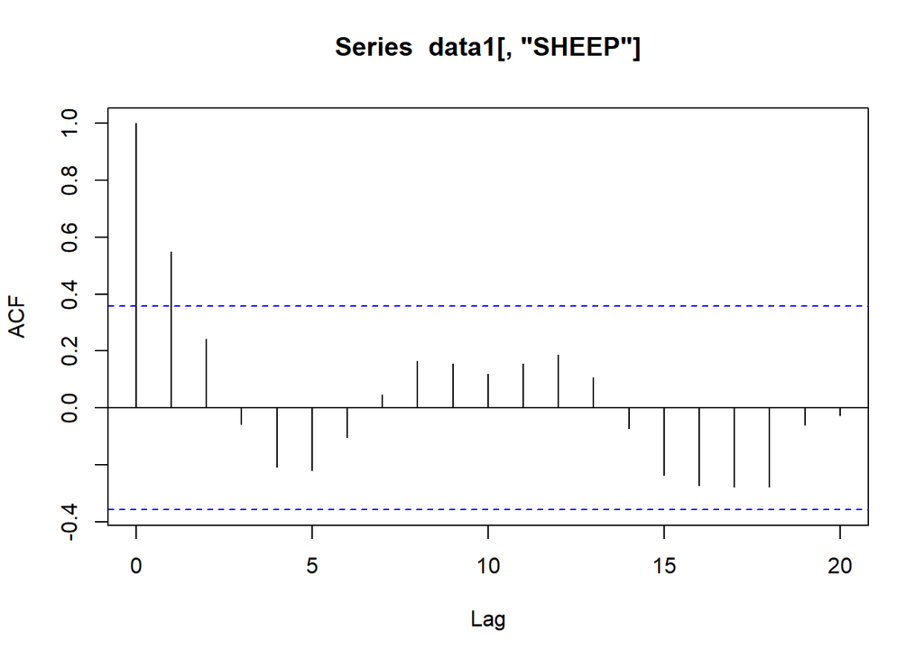

```r
acf(data1[,"SHEEP"], lag.max = 20)
```

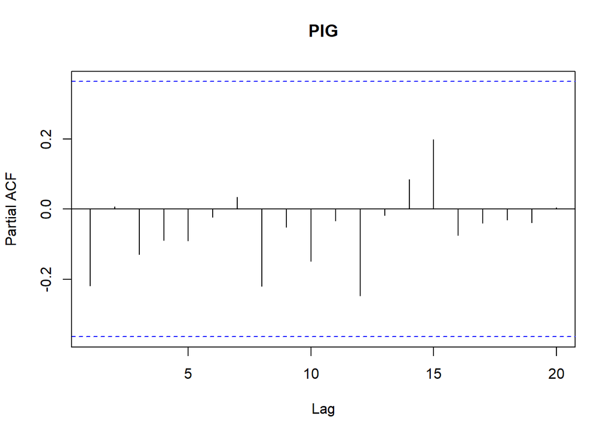

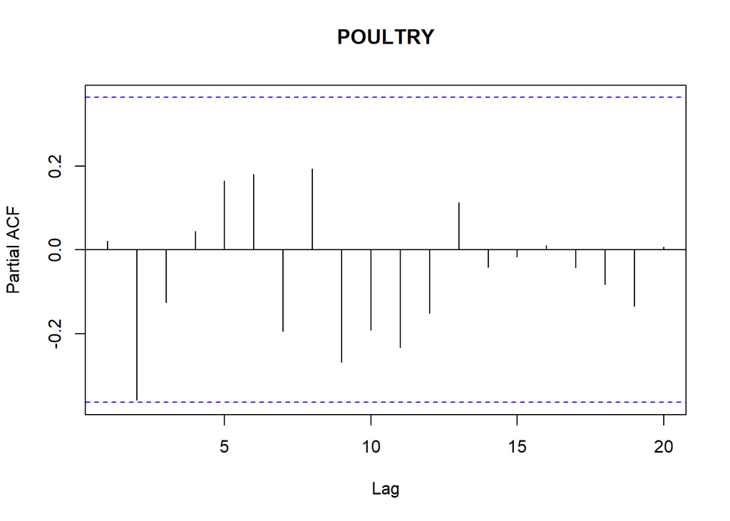

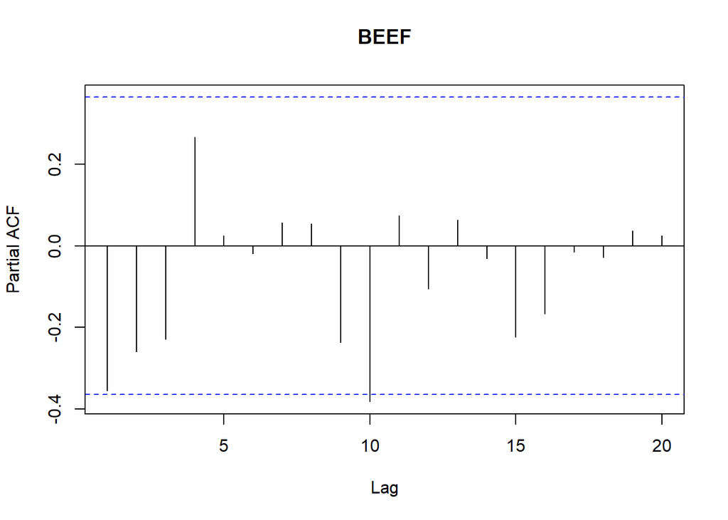

```r
# removing the trend


# ACF
n <- length(4)
for(i in 1:3){
pacf(diff(data1[,i]), main = colnames(data1)[i], lag.max = 20)
}
```

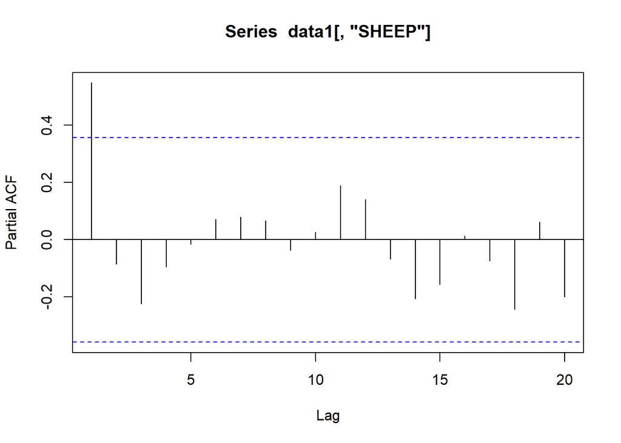

```r
pacf(data1[,"SHEEP"], lag.max = 20)
```

Based on KPSS test we made ACF and PACF plot for differentiated BEEF, PIG & POULTRY. Also ACF & PACF plot for original SHEEP data. stationary : Sheep data is stationary and others are not stationary based on KPSS test.

ARIMA parameter suggestion: PIG : ARIMA(0,1,0) POULTRY : ARIMA(0,1,0) BEEF : ARIMA(10,1,0) Because the is no spike in pace and ACF plot and also d=1 because it had a trend. sheep has no trend so d is 0 for ARIMA MODEL and based on PACF and ACF ARIMA(0,0,1)

## b)

Divide the dataset into training (20 years) and testing (9 years). For each meat type, train 4 baseline models (average, drift, naive, seasonal naive) and compute the RMSE on the test set. Further, build an exponential smoothing and an ARIMA model and plot the forecasts. Describe how you select the type of exponential smoothing (model parameter in the ets() function). Provide a matrix showing the RMSE on the test set for all models (see Tab. 1).

Scaling &Train and Test split

```
## For a multivariate time series, specify a seriesname for each time series. Defaulting to column names.
```

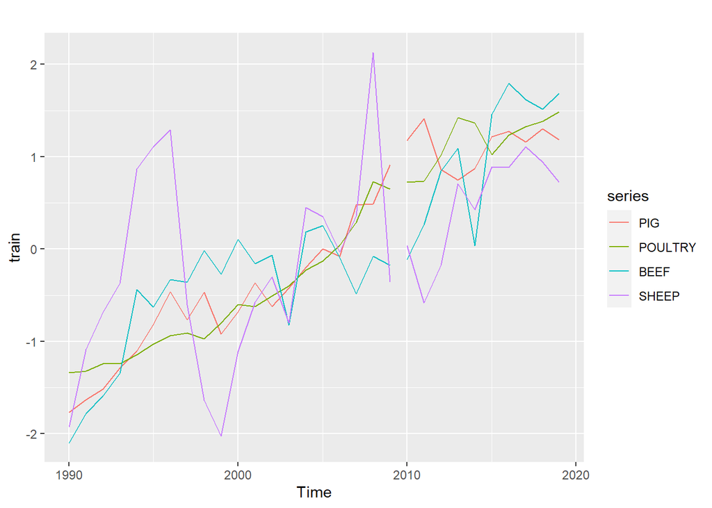

```r
data1 <- scale(data1)
# Training set
# Use data from 1990 to 2009 for forecasting
train = window(data1, start=1990, end=2009)


# Test set
# Use remaining data from 2012 to 2019 to test accuracy
test = window(data1, start=2010)
autoplot(train) + autolayer(test)
```

Four Baseline Models

```r
colnames(train)
```

```
## [1] "PIG"     "POULTRY" "BEEF"    "SHEEP"
```

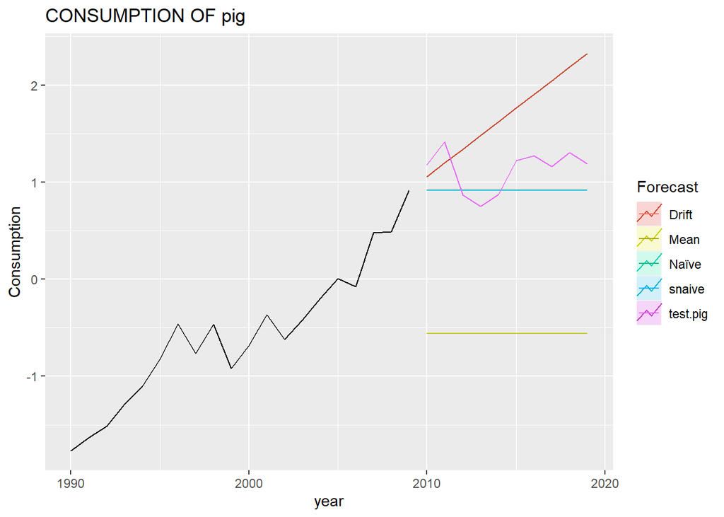

```r
Pig <- train[,"PIG"]
test.pig <- test[,"PIG"]


autoplot(Pig) +
  autolayer(meanf(Pig, h=10),
    series="Mean", PI=FALSE) +
  autolayer(rwf(Pig, h=10),
    series="Naïve", PI=FALSE) +
  autolayer(rwf(Pig, h=10),
    series="snaive", PI=FALSE) +
  autolayer(rwf(Pig, drift=TRUE, h=10),
    series="Drift", PI=FALSE) +
   autolayer(test.pig) +
  ggtitle("CONSUMPTION OF pig") +
  xlab("year") + ylab("Consumption") +
  guides(colour=guide_legend(title="Forecast"))
```

```r
# average method
mod_avg_pig <- meanf(Pig , h = 10)
#summary(mod_avg)

# drift model
mod_drift_pig <- rwf(Pig , drift = TRUE , h = 10)
#summary(mod_drift)
# naive method
mod_naive_pig <- naive(Pig , h = 10)
#summary(mod_naive)
# seasonal naive method
mod_snaive_pig <- snaive(Pig , h = 10)
#summary(mod_snaive)


df_avg_pig = as.data.frame(mod_avg_pig)
df_drift_pig = as.data.frame(mod_drift_pig)
df_naive_pig = as.data.frame(mod_naive_pig)
df_snaive_pig = as.data.frame(mod_snaive_pig)

rmse(test.pig ,df_avg_pig$`Point Forecast`)
```

```
## [1] 1.695106
```

```r
rmse(test.pig ,df_drift_pig$`Point Forecast`)
```

```
## [1] 0.7025031
```

```r
rmse(test.pig ,df_naive_pig$`Point Forecast`)
```

```
## [1] 0.2917365
```

```r
rmse(test.pig ,df_snaive_pig$`Point Forecast`)
```

```
## [1] 0.2917365
```

```r
colnames(train)
```

```
## [1] "PIG"     "POULTRY" "BEEF"    "SHEEP"
```

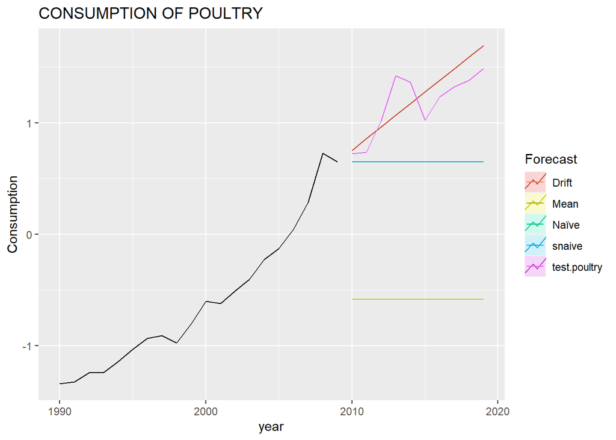

```r
POULTRY <- train[,"POULTRY"]
test.poultry <- test[,"POULTRY"]

autoplot(POULTRY) +
  autolayer(meanf(POULTRY, h=10),
    series="Mean", PI=FALSE) +
  autolayer(rwf(POULTRY, h=10),
    series="Naïve", PI=FALSE) +
  autolayer(rwf(POULTRY, h=10),
    series="snaive", PI=FALSE) +
  autolayer(rwf(POULTRY, drift=TRUE, h=10),
    series="Drift", PI=FALSE) +
  autolayer(test.poultry) +
  ggtitle("CONSUMPTION OF POULTRY") +
  xlab("year") + ylab("Consumption") +
  guides(colour=guide_legend(title="Forecast"))
```

```r
# average method
mod_avg_poultry <- meanf(POULTRY , h = 10)
#summary(mod_avg)
# drift model
mod_drift_poultry <- rwf(POULTRY , drift = TRUE , h = 10)
#summary(mod_drift)
# naive method
mod_naive_poultry  <- naive(POULTRY , h = 10)
#summary(mod_naive)
# seasonal naive method
mod_snaive_poultry  <- snaive(POULTRY , h = 10)
#summary(mod_snaive)

df_avg_poultry  = as.data.frame(mod_avg_poultry)
df_drift_poultry  = as.data.frame(mod_drift_poultry)
df_naive_poultry  = as.data.frame(mod_naive_poultry)
df_snaive_poultry  = as.data.frame(mod_snaive_poultry)

rmse(test.pig ,df_avg_poultry $`Point Forecast`)
```

```
## [1] 1.719989
```

```r
rmse(test.pig ,df_drift_poultry $`Point Forecast`)
```

```
## [1] 0.3393789
```

```r
rmse(test.pig ,df_naive_poultry $`Point Forecast`)
```

```
## [1] 0.5151472
```

```r
rmse(test.pig ,df_snaive_poultry $`Point Forecast`)
```

```
## [1] 0.5151472
```

```r
colnames(train)
```

```
## [1] "PIG"     "POULTRY" "BEEF"    "SHEEP"
```

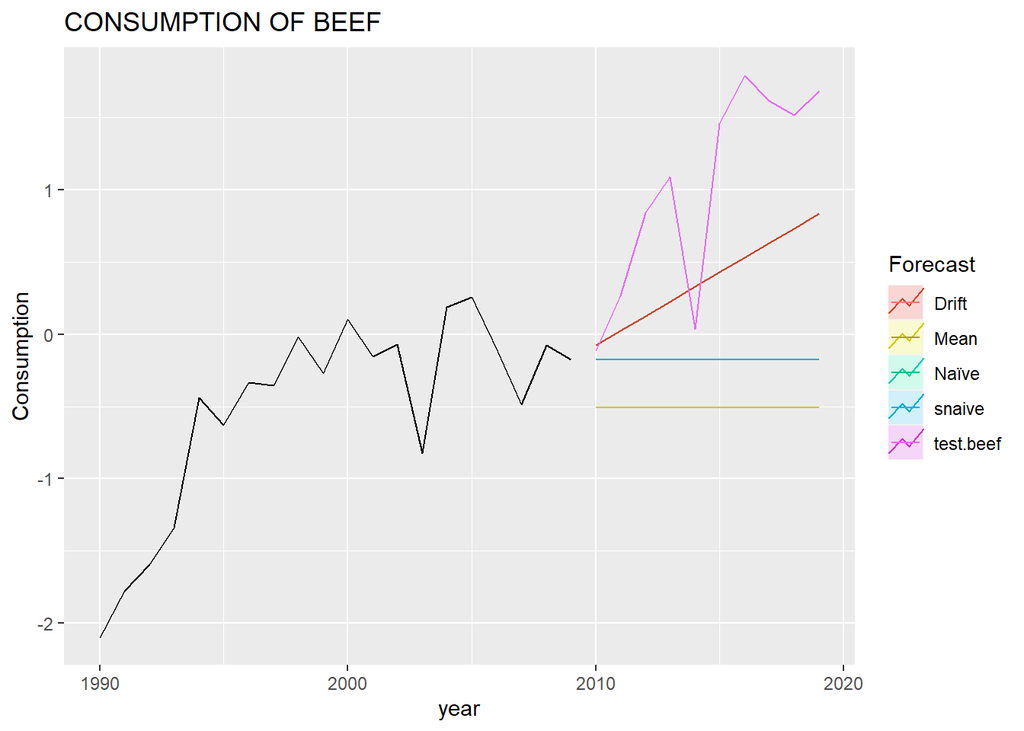

```r
BEEF <- train[,"BEEF"]
test.beef <- test[,"BEEF"]

autoplot(BEEF) +
  autolayer(meanf(BEEF, h=10),
    series="Mean", PI=FALSE) +
  autolayer(rwf(BEEF, h=10),
    series="Naïve", PI=FALSE) +
  autolayer(rwf(BEEF, h=10),
    series="snaive", PI=FALSE) +
  autolayer(rwf(BEEF, drift=TRUE, h=10),
    series="Drift", PI=FALSE) +
  autolayer(test.beef) +
  ggtitle("CONSUMPTION OF BEEF") +
  xlab("year") + ylab("Consumption") +
  guides(colour=guide_legend(title="Forecast"))
```

```r
# average method
mod_avg_beef <- meanf(BEEF , h = 10)
#summary(mod_avg)
# drift model
mod_drift_beef <- rwf(BEEF , drift = TRUE , h = 10)
#summary(mod_drift)
# naive method
mod_naive_beef <- naive(BEEF , h = 10)
#summary(mod_naive)
# seasonal naive method
mod_snaive_beef <- snaive(BEEF , h = 10)
#summary(mod_snaive)

df_avg_beef = as.data.frame(mod_avg_beef)
df_drift_beef = as.data.frame(mod_drift_beef)
df_naive_beef = as.data.frame(mod_naive_beef)
df_snaive_beef = as.data.frame(mod_snaive_beef)

rmse(test.pig ,df_avg_beef$`Point Forecast`)
```

```
## [1] 1.644413
```

```r
rmse(test.pig ,df_drift_beef$`Point Forecast`)
```

```
## [1] 0.8061863
```

```r
rmse(test.pig ,df_naive_beef$`Point Forecast`)
```

```
## [1] 1.314553
```

```r
rmse(test.pig ,df_snaive_beef$`Point Forecast`)
```

```
## [1] 1.314553
```

```r
colnames(train)
```

```
## [1] "PIG"     "POULTRY" "BEEF"    "SHEEP"
```

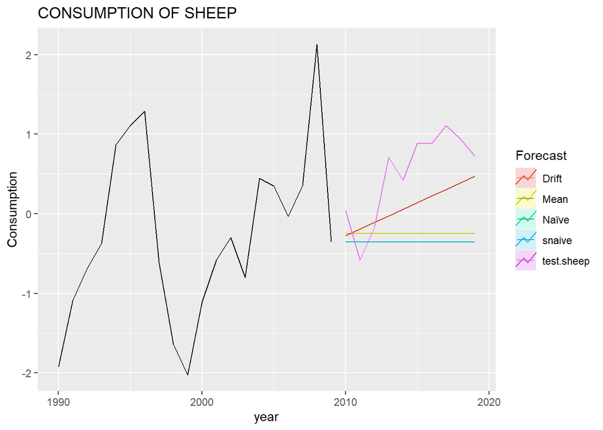

```r
SHEEP <- train[,"SHEEP"]
test.sheep <- test[,"SHEEP"]

autoplot(SHEEP) +
  autolayer(meanf(SHEEP, h=10),
    series="Mean", PI=FALSE) +
  autolayer(rwf(SHEEP, h=10),
    series="Naïve", PI=FALSE) +
  autolayer(rwf(SHEEP, h=10),
    series="snaive", PI=FALSE) +
  autolayer(rwf(SHEEP, drift=TRUE, h=10),
    series="Drift", PI=FALSE) +
  autolayer(test.sheep) +
  ggtitle("CONSUMPTION OF SHEEP") +
  xlab("year") + ylab("Consumption") +
  guides(colour=guide_legend(title="Forecast"))
```

```r
# average method
mod_avg_sheep <- meanf(SHEEP , h = 10)
#summary(mod_avg)
# drift model
mod_drift_sheep <- rwf(SHEEP , drift = TRUE , h = 10)
#summary(mod_drift)
# naive method
mod_naive_sheep <- naive(SHEEP , h = 10)
#summary(mod_naive)
# seasonal naive method
mod_snaive_sheep <- snaive(SHEEP , h = 10)
#summary(mod_snaive)

df_avg_sheep = as.data.frame(mod_avg_sheep)
df_drift_sheep = as.data.frame(mod_drift_sheep)
df_naive_sheep = as.data.frame(mod_naive_sheep)
df_snaive_sheep = as.data.frame(mod_snaive_sheep)
rmse(test.pig ,df_avg_sheep$`Point Forecast`)
```

```
## [1] 1.385457
```

```r
rmse(test.pig ,df_drift_sheep$`Point Forecast`)
```

```
## [1] 1.059693
```

```r
rmse(test.pig ,df_naive_sheep$`Point Forecast`)
```

```
## [1] 1.49218
```

```r
rmse(test.pig ,df_snaive_sheep$`Point Forecast`)
```

```
## [1] 1.49218
```

ARIMA Models

```r
mod_arima_pig <- auto.arima(Pig)
# model summary
summary(mod_arima_pig)
```

```
## Series: Pig
## ARIMA(1,1,0) with drift
##
## Coefficients:
##           ar1   drift
##       -0.4642  0.1363
## s.e.   0.2016  0.0350
##
## sigma^2 = 0.05382:  log likelihood = 1.74
## AIC=2.53   AICc=4.13   BIC=5.36
##
## Training set error measures:
##                         ME      RMSE       MAE      MPE     MAPE     MASE
## Training set -7.676172e-05 0.2138821 0.1701178 171.8992 193.5857 0.664937
##                     ACF1
## Training set -0.01661769
```

```r
# model parameters
#mod_arima$coef
# 12-step -ahead forecast
df_arima_pig <- forecast(mod_arima_pig , h = 10)
df_arima_pig = as.data.frame(df_arima_pig)
rmse(test.pig ,df_arima_pig$`Point Forecast`)
```

```
## [1] 0.6032129
```

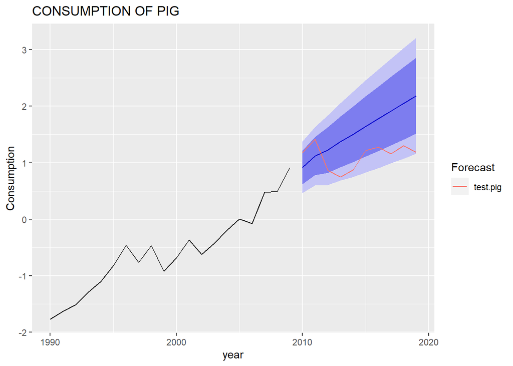

```r
autoplot(Pig) +
  autolayer(forecast(mod_arima_pig , h = 10))+
  autolayer(test.pig) +
  ggtitle("CONSUMPTION OF PIG") +
  xlab("year") + ylab("Consumption") +
  guides(colour=guide_legend(title="Forecast"))
```

```r
mod_arima_poultry <- auto.arima(POULTRY)
# model summary
summary(mod_arima_poultry)
```

```
## Series: POULTRY
## ARIMA(0,1,0) with drift
##
## Coefficients:
##        drift
##       0.1047
## s.e.  0.0268
##
## sigma^2 = 0.01443:  log likelihood = 13.82
## AIC=-23.64   AICc=-22.89   BIC=-21.75
##
## Training set error measures:
##                         ME      RMSE        MAE      MPE     MAPE      MASE
## Training set -7.216821e-05 0.1139685 0.07949364 11.62649 20.22275 0.6501989
##                     ACF1
## Training set -0.02062773
```

```r
# model parameters
#mod_arima$coef
# 12-step -ahead forecast
forecast(mod_arima_poultry , h = 10)
```

```
##      Point Forecast     Lo 80     Hi 80     Lo 95    Hi 95
## 2010      0.7542990 0.6003420 0.9082561 0.5188420 0.989756
## 2011      0.8589497 0.6412215 1.0766778 0.5259632 1.191936
## 2012      0.9636003 0.6969389 1.2302618 0.5557769 1.371424
## 2013      1.0682510 0.7603369 1.3761651 0.5973370 1.539165
## 2014      1.1729017 0.8286432 1.5171601 0.6464038 1.699400
## 2015      1.2775523 0.9004361 1.6546686 0.7008029 1.854302
## 2016      1.3822030 0.9748709 1.7895351 0.7592424 2.005164
## 2017      1.4868537 1.0513974 1.9223100 0.8208807 2.152827
## 2018      1.5915043 1.1296332 2.0533755 0.8851334 2.297875
## 2019      1.6961550 1.2093001 2.1830100 0.9515746 2.440735
```

```r
df_arima_poultry <- forecast(mod_arima_poultry , h = 10)
df_arima_poultry = as.data.frame(df_arima_poultry)
rmse(test.poultry ,df_arima_poultry$`Point Forecast`)
```

```
## [1] 0.1954866
```

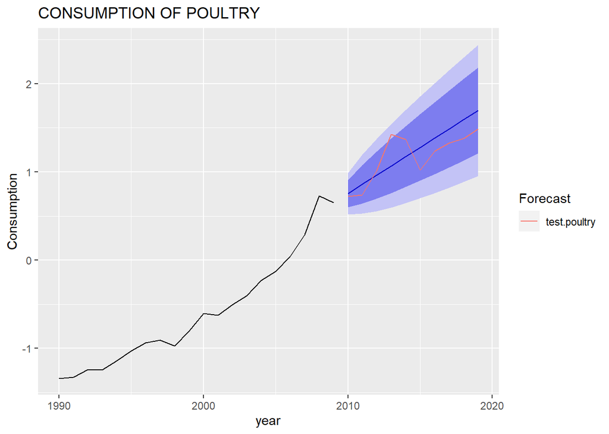

```r
autoplot(POULTRY) +
  autolayer(forecast(mod_arima_poultry , h = 10))+
  autolayer(test.poultry) +
  ggtitle("CONSUMPTION OF POULTRY") +
  xlab("year") + ylab("Consumption") +
  guides(colour=guide_legend(title="Forecast"))
```

```r
mod_arima_beef <- auto.arima(BEEF)
# model summary
summary(mod_arima_beef)
```

```
## Series: BEEF
## ARIMA(0,1,0)
##
## sigma^2 = 0.1888:  log likelihood = -11.12
## AIC=24.24   AICc=24.48   BIC=25.19
##
## Training set error measures:
##                      ME      RMSE       MAE       MPE     MAPE      MASE
## Training set 0.09598622 0.4235042 0.3286812 -56.44012 238.4591 0.9503034
##                    ACF1
## Training set -0.3718812
```

```r
# 10-step -ahead forecast
forecast(mod_arima_beef , h = 10)
```

```
##      Point Forecast      Lo 80     Hi 80     Lo 95     Hi 95
## 2010     -0.1765908 -0.7334329 0.3802513 -1.028207 0.6750256
## 2011     -0.1765908 -0.9640845 0.6109028 -1.380958 1.0277767
## 2012     -0.1765908 -1.1410696 0.7878879 -1.651634 1.2984522
## 2013     -0.1765908 -1.2902750 0.9370933 -1.879824 1.5266421
## 2014     -0.1765908 -1.4217276 1.0685459 -2.080863 1.7276815
## 2015     -0.1765908 -1.5405698 1.1873881 -2.262617 1.9094350
## 2016     -0.1765908 -1.6498565 1.2966748 -2.429756 2.0765746
## 2017     -0.1765908 -1.7515781 1.3983964 -2.585326 2.2321443
## 2018     -0.1765908 -1.8471171 1.4939354 -2.731440 2.3782586
## 2019     -0.1765908 -1.9374801 1.5842984 -2.869639 2.5164569
```

```r
df_arima_beef <- forecast(mod_arima_beef , h = 10)
df_arima_beef = as.data.frame(df_arima_beef)
rmse(test.beef ,df_arima_beef$`Point Forecast`)
```

```
## [1] 1.378378
```

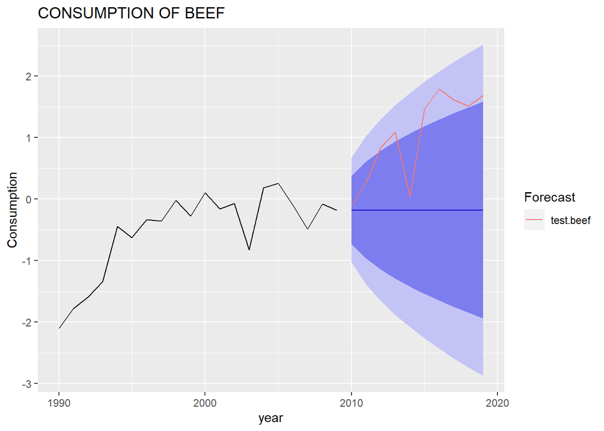

```r
autoplot(BEEF) +
  autolayer(forecast(mod_arima_beef , h = 10))+
  autolayer(test.beef) +
  ggtitle("CONSUMPTION OF BEEF") +
  xlab("year") + ylab("Consumption") +
  guides(colour=guide_legend(title="Forecast"))
```

```r
mod_arima_sheep <- auto.arima(SHEEP)
# model summary
summary(mod_arima_sheep)
```

```
## Series: SHEEP
## ARIMA(1,0,0) with zero mean
##
## Coefficients:
##          ar1
##       0.5584
## s.e.  0.1944
##
## sigma^2 = 0.8825:  log likelihood = -26.8
## AIC=57.61   AICc=58.31   BIC=59.6
##
## Training set error measures:
##                      ME      RMSE       MAE      MPE     MAPE      MASE
## Training set -0.1031858 0.9156366 0.6801162 113.7687 115.7366 0.8538125
##                    ACF1
## Training set 0.03774236
```

```r
# 10-step -ahead forecast
forecast(mod_arima_sheep , h = 10)
```

```
##      Point Forecast     Lo 80    Hi 80     Lo 95    Hi 95
## 2010   -0.198888857 -1.402808 1.005031 -2.040125 1.642347
## 2011   -0.111058890 -1.489958 1.267840 -2.219903 1.997785
## 2012   -0.062014923 -1.491098 1.367069 -2.247610 2.123580
## 2013   -0.034628931 -1.479004 1.409746 -2.243610 2.174352
## 2014   -0.019336682 -1.468447 1.429773 -2.235559 2.196886
## 2015   -0.010797540 -1.461381 1.439786 -2.229273 2.207678
## 2016   -0.006029311 -1.457072 1.445013 -2.225207 2.213148
## 2017   -0.003366748 -1.454552 1.447819 -2.222763 2.216030
## 2018   -0.001879981 -1.453110 1.449350 -2.221345 2.217585
## 2019   -0.001049775 -1.452294 1.450194 -2.220536 2.218436
```

```r
df_arima_sheep <- forecast(mod_arima_sheep , h = 10)
df_arima_sheep = as.data.frame(df_arima_sheep)
rmse(test.sheep ,df_arima_sheep$`Point Forecast`)
```

```
## [1] 0.728155
```

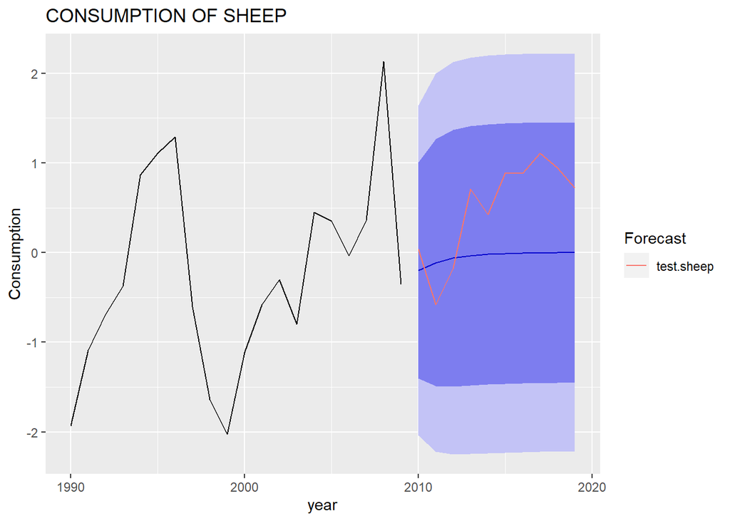

```r
autoplot(SHEEP) +
  autolayer(forecast(mod_arima_sheep , h = 10))+
  autolayer(test.sheep) +
  ggtitle("CONSUMPTION OF SHEEP") +
  xlab("year") + ylab("Consumption") +
  guides(colour=guide_legend(title="Forecast"))
```

Exponetial Smoothing Model  
We perform Holt ETS damped model on Pig , Beef and Poultry data because they have a trend behavior and the damped one flatten up the predictions after the steps that we want but we used ses method for Sheep data because of having no trend.

```r
mod_holt_pig <- ets(Pig , model = "AAN", damped = TRUE) # Holt method (damped)

# model summary
summary(mod_holt_pig)
```

```
## ETS(A,Ad,N)
##
## Call:
##  ets(y = Pig, model = "AAN", damped = TRUE)
##
##   Smoothing parameters:
##     alpha = 0.6273
##     beta  = 0.0044
##     phi   = 0.98
##
##   Initial states:
##     l = -1.9306
##     b = 0.163
##
##   sigma:  0.259
##
##      AIC     AICc      BIC
## 12.13141 18.59295 18.10581
##
## Training set error measures:
##                       ME      RMSE       MAE      MPE     MAPE      MASE
## Training set 0.006521977 0.2243426 0.1661236 191.4794 209.6985 0.6493251
##                     ACF1
## Training set -0.09134429
```

```r
# 10-step -ahead forecast
df_holt_pig <- forecast(mod_holt_pig , h = 10)

rmse(test.pig ,df_holt_pig$mean)
```

```
## [1] 0.3831874
```

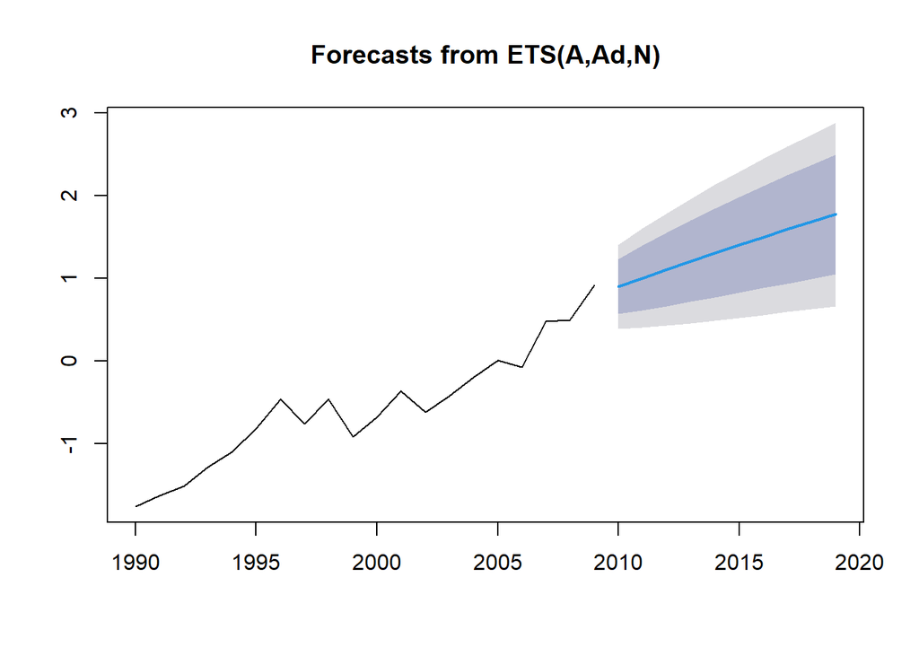

```r
# plot
plot(df_holt_pig)
```

```r
mod_holt_poultry <- ets(POULTRY , model = "AAN", damped = TRUE) # Holt method (damped)

# model summary
summary(mod_holt_poultry)
```

```
## ETS(A,Ad,N)
##
## Call:
##  ets(y = POULTRY, model = "AAN", damped = TRUE)
##
##   Smoothing parameters:
##     alpha = 0.3102
##     beta  = 0.2991
##     phi   = 0.98
##
##   Initial states:
##     l = -1.4367
##     b = 0.0548
##
##   sigma:  0.1272
##
##        AIC       AICc        BIC
## -16.332486  -9.870947 -10.358092
##
## Training set error measures:
##                      ME      RMSE       MAE      MPE     MAPE      MASE
## Training set 0.03888056 0.1101207 0.0754503 5.518165 20.25221 0.6171274
##                     ACF1
## Training set -0.03533603
```

```r
# 10-step -ahead forecast
df_holt_poultry <- forecast(mod_holt_poultry , h = 10)

rmse(test.poultry ,df_holt_poultry$mean)
```

```
## [1] 0.9378021
```

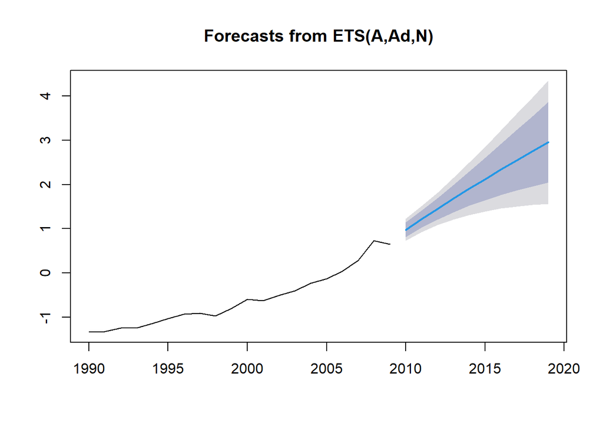

```r
# plot
plot(df_holt_poultry)
```

```r
mod_holt_beef <- ets(BEEF , model = "AAN", damped = TRUE) # Holt method (damped)

# model summary
summary(mod_holt_beef)
```

```
## ETS(A,Ad,N)
##
## Call:
##  ets(y = BEEF, model = "AAN", damped = TRUE)
##
##   Smoothing parameters:
##     alpha = 3e-04
##     beta  = 3e-04
##     phi   = 0.8
##
##   Initial states:
##     l = -2.5998
##     b = 0.6527
##
##   sigma:  0.3178
##
##      AIC     AICc      BIC
## 20.30208 26.76362 26.27647
##
## Training set error measures:
##                        ME      RMSE       MAE       MPE     MAPE     MASE
## Training set -0.004566027 0.2751843 0.2074558 -56.29335 156.6042 0.599809
##                     ACF1
## Training set -0.03470079
```

```r
# model parameters
mod_holt_beef$par
```

```
##         alpha          beta           phi             l             b
##  0.0002537553  0.0002501287  0.8000000021 -2.5998011713  0.6526515525
```

```r
# 10-step -ahead forecast
df_holt_beef <- forecast(mod_holt_beef , h = 10)

rmse(test.beef ,df_holt_beef$mean)
```

```
## [1] 1.225189
```

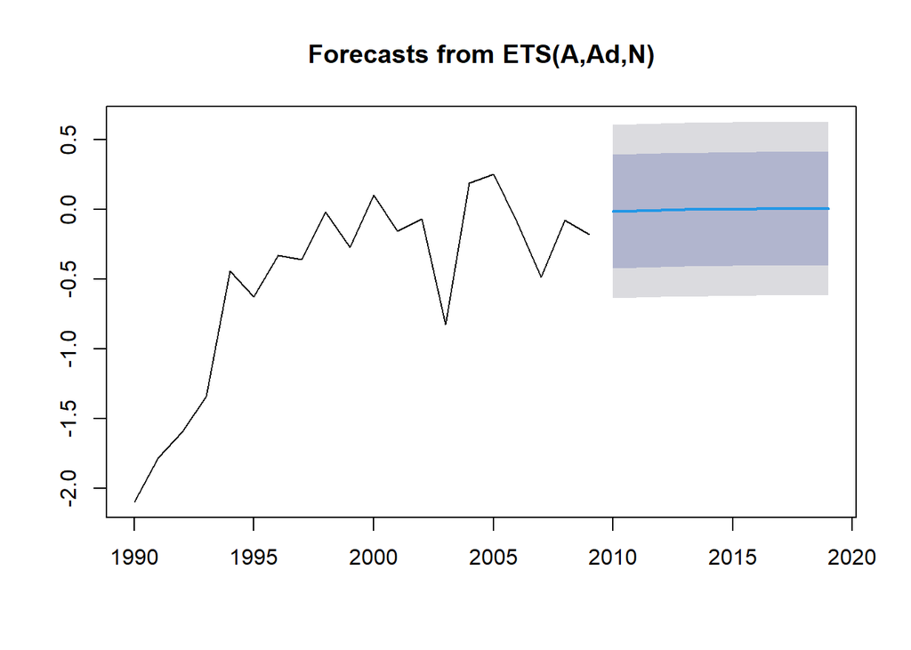

```r
# plot
plot(df_holt_beef)
```

```r
sheep_ses <- ets(SHEEP , model = "ANN") # SES method

# model summary
summary(sheep_ses)
```

```
## ETS(A,N,N)
##
## Call:
##  ets(y = SHEEP, model = "ANN")
##
##   Smoothing parameters:
##     alpha = 0.8783
##
##   Initial states:
##     l = -1.8186
##
##   sigma:  1.0513
##
##     AIC    AICc     BIC
## 65.8090 67.3090 68.7962
##
## Training set error measures:
##                      ME      RMSE       MAE      MPE     MAPE      MASE
## Training set 0.09894925 0.9973624 0.7866835 116.7359 172.1987 0.9875963
##                     ACF1
## Training set -0.01060084
```

```r
# 10-step -ahead forecast
df_ses_sheep <- forecast(sheep_ses , h = 10)

rmse(as.vector(test.sheep),as.vector(df_ses_sheep$mean))
```

```
## [1] 0.7833131
```

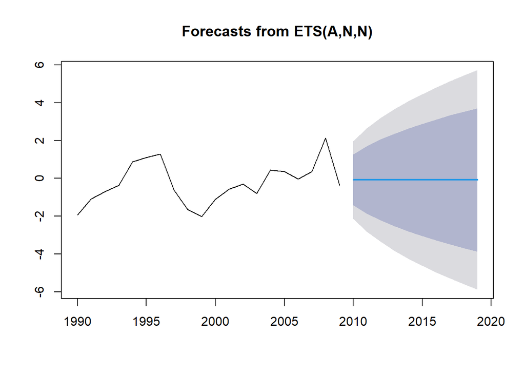

```r
# plot
plot(df_ses_sheep)
```

```r
Model <- c("Mean" , "Drift" , "Naive" , "Snaive" , "ARIMA" , "EST")
PIG <- c(rmse(test.pig ,df_avg_pig$`Point Forecast`),
rmse(test.pig ,df_drift_pig$`Point Forecast`),
rmse(test.pig ,df_naive_pig$`Point Forecast`),
rmse(test.pig ,df_snaive_pig$`Point Forecast`),
rmse(test.pig ,df_arima_pig$`Point Forecast`),
rmse(test.pig ,df_holt_pig$mean))
POULTRY <-c(rmse(test.pig ,df_avg_poultry $`Point Forecast`),
rmse(test.pig ,df_drift_poultry $`Point Forecast`),
rmse(test.pig ,df_naive_poultry $`Point Forecast`),
rmse(test.pig ,df_snaive_poultry $`Point Forecast`),
rmse(test.poultry ,df_arima_poultry$`Point Forecast`),
rmse(test.poultry ,df_holt_poultry$mean))
BEEF <-c(rmse(test.pig ,df_avg_beef$`Point Forecast`),
rmse(test.pig ,df_drift_beef$`Point Forecast`),
rmse(test.pig ,df_naive_beef$`Point Forecast`),
rmse(test.pig ,df_snaive_beef$`Point Forecast`),
rmse(test.beef ,df_arima_beef$`Point Forecast`),
rmse(test.beef ,df_holt_beef$mean))
SHEEP <-c(rmse(test.pig ,df_avg_sheep$`Point Forecast`),
rmse(test.pig ,df_drift_sheep$`Point Forecast`),
rmse(test.pig ,df_naive_sheep$`Point Forecast`),
rmse(test.pig ,df_snaive_sheep$`Point Forecast`),
rmse(test.sheep ,df_arima_sheep$`Point Forecast`),
rmse(test.sheep ,df_ses_sheep$mean))


df <- data.frame(Model, PIG , POULTRY, BEEF , SHEEP)
df
```

```
##    Model       PIG   POULTRY      BEEF     SHEEP
## 1   Mean 1.6951057 1.7199894 1.6444130 1.3854566
## 2  Drift 0.7025031 0.3393789 0.8061863 1.0596931
## 3  Naive 0.2917365 0.5151472 1.3145526 1.4921804
## 4 Snaive 0.2917365 0.5151472 1.3145526 1.4921804
## 5  ARIMA 0.6032129 0.1954866 1.3783782 0.7281550
## 6    EST 0.3831874 0.9378021 1.2251895 0.7833131
```

## c)

Describe the benefits and drawbacks of the models applied in task (b). Take the properties of the time series into account. Which model performs best?

According to models that we performed in task b and mertrics that there are at the last part of that ,we can say that mean baseline has the worst result for prediction except to SHEEP data because it takes the avarage of data and give this average value to the future data which is not precise. But in Sheep data we can see stationary in that and based on that average model works well.

Naive and Snaive model has nice performance on PIG data and it decreases RMSE so much but it does not change performance in POULTRY and BEEF data also in SHEEP data it has worst performance.

finally, ETS model has not good performance on the data except for PIG data. In result, ARIMA model has better performance on average.

## d)

According to Hyndman and Athanasopoulos (2021, chapter 9.10, https: // otexts. com/ fpp3/ arima-ets. html ), certain types of exponential smoothing models are special cases of ARIMA models. Considering only beef, compute the ARIMA parameters for the exponential smoothing model used in (b) using the formula in the book. Use the computed parameters in R to perform a forecast. The parameters can be used in the fixed argument of the forecast::arima() function. Compare the results with models in (b).

Based on task b the parameters are:

so we have : $\varphi_1 = \phi = 0.8$

```r
BEEF <- train[,"BEEF"]
test.beef <- test[,"BEEF"]

arima_ets_beef <- arima(BEEF , order =c(1,1,2) ,fixed = c(phi_1 = 0.8, theta_1 = -1.73664 , theta_2 = 0.77))

summary(arima_ets_beef)
```

```
##
## Call:
## arima(x = BEEF, order = c(1, 1, 2), fixed = c(phi_1 = 0.8, theta_1 = -1.73664,
##     theta_2 = 0.77))
##
## Coefficients:
##     ar1      ma1      ma2
##  0.8000  -1.7366   0.7700
##
## sigma^2 estimated as 0.4413:  log likelihood = -19.97,  aic = 41.94
##
## Training set error measures:
##                     ME    RMSE       MAE       MPE     MAPE     MASE      ACF1
## Training set 0.4912534 0.64751 0.5443601 -366.2989 528.3413 1.573888 0.4428653
```

```r
df_arima_ets_beef <- forecast(arima_ets_beef , h = 10)
df_arima_ets_beef = as.data.frame(df_arima_ets_beef)
rmse(test.beef ,df_arima_ets_beef$`Point Forecast`)
```

```
## [1] 1.287063
```

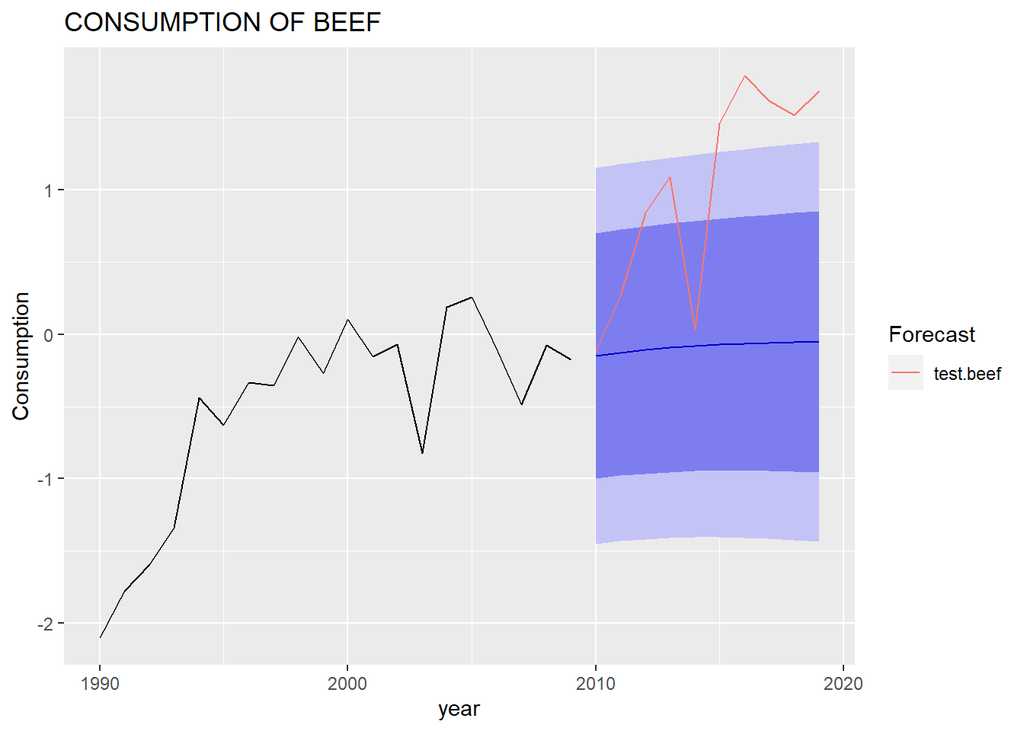

```r
autoplot(BEEF) +
  autolayer(forecast(arima_ets_beef , h = 10))+
  autolayer(test.beef) +
  ggtitle("CONSUMPTION OF BEEF") +
  xlab("year") + ylab("Consumption") +
  guides(colour=guide_legend(title="Forecast"))
```

# Exercise 2

## a)

- Loading all the library`s we need
- Loading the dataset

```r
death <- read.csv("data//USAccidents.csv", header = TRUE, sep = ",")
death$date <- as.Date(death$date)
```

- Exploring the dataset, before we make it to time series data

```r
dim(death)
```

```
## [1] 72  2
```

- We see that we have 72 observations and two columns

```r
head(death)
```

```
##         date accident_deaths
## 1 1973-01-01            9007
## 2 1973-02-01            8106
## 3 1973-03-01            8928
## 4 1973-04-01            9137
## 5 1973-05-01           10017
## 6 1973-06-01           10826
```

- We see that the date is one colum and accident deaths are another

```r
summary(death)
```

```
##       date            accident_deaths
##  Min.   :1973-01-01   Min.   : 6892
##  1st Qu.:1974-06-23   1st Qu.: 8089
##  Median :1975-12-16   Median : 8728
##  Mean   :1975-12-16   Mean   : 8789
##  3rd Qu.:1977-06-08   3rd Qu.: 9323
##  Max.   :1978-12-01   Max.   :11317
```

- We see that we have a very close normally distributed data, we look at the mean and median which are very alike
- Plot the data on the basis of year

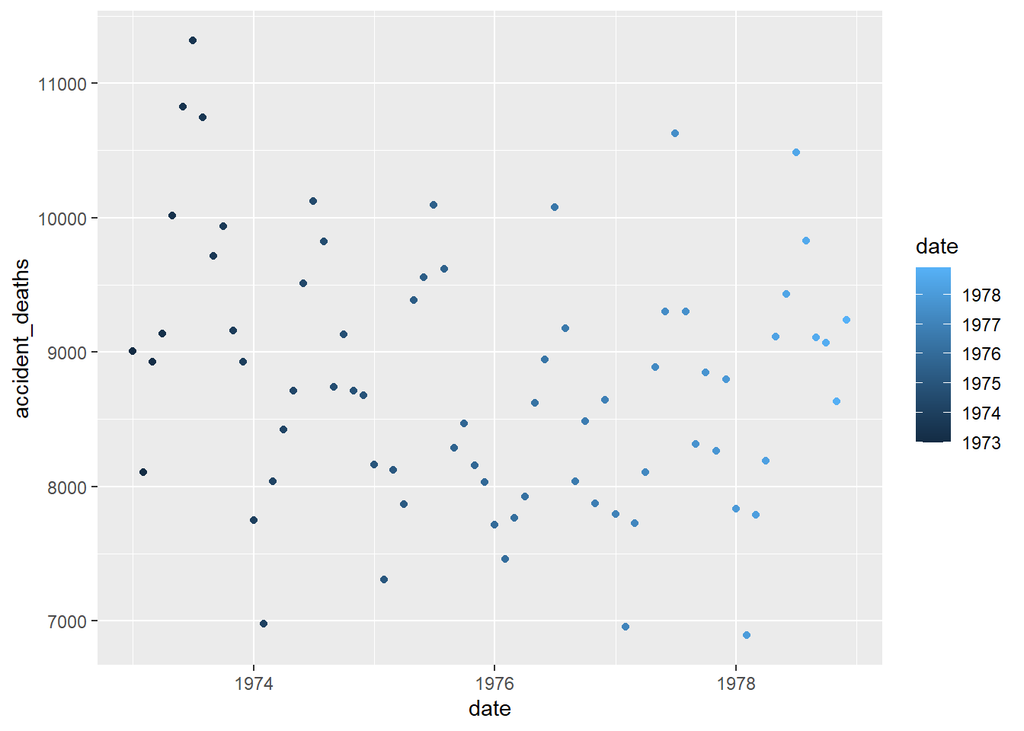

```r
ggplot(data = death, aes(x = date, y =accident_deaths, color = date)) +
  geom_point()
```

- In this plot we see that the highest death rates, the dark blue on the top are from some of the earlier years.
- We visual this with year one the x-axis and counts on the y-axis.

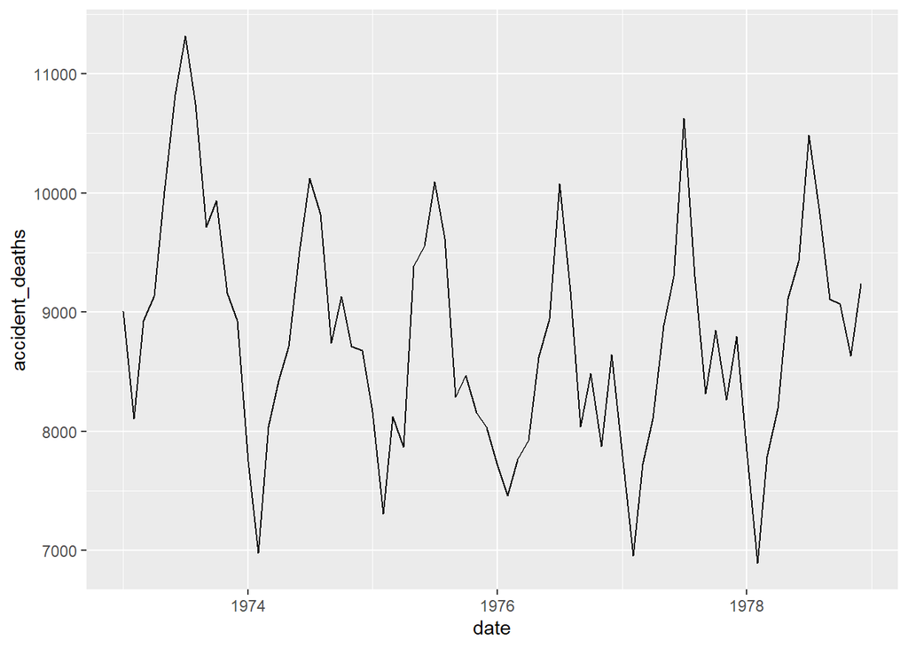

```r
ggplot(data = death, aes( x = date, y = accident_deaths)) +
  geom_line()
```

- With this plot we can see that better we se that we have a top at 1973 which is the highest.
- Auto and cross correlation on the original data frame, just to look at it.

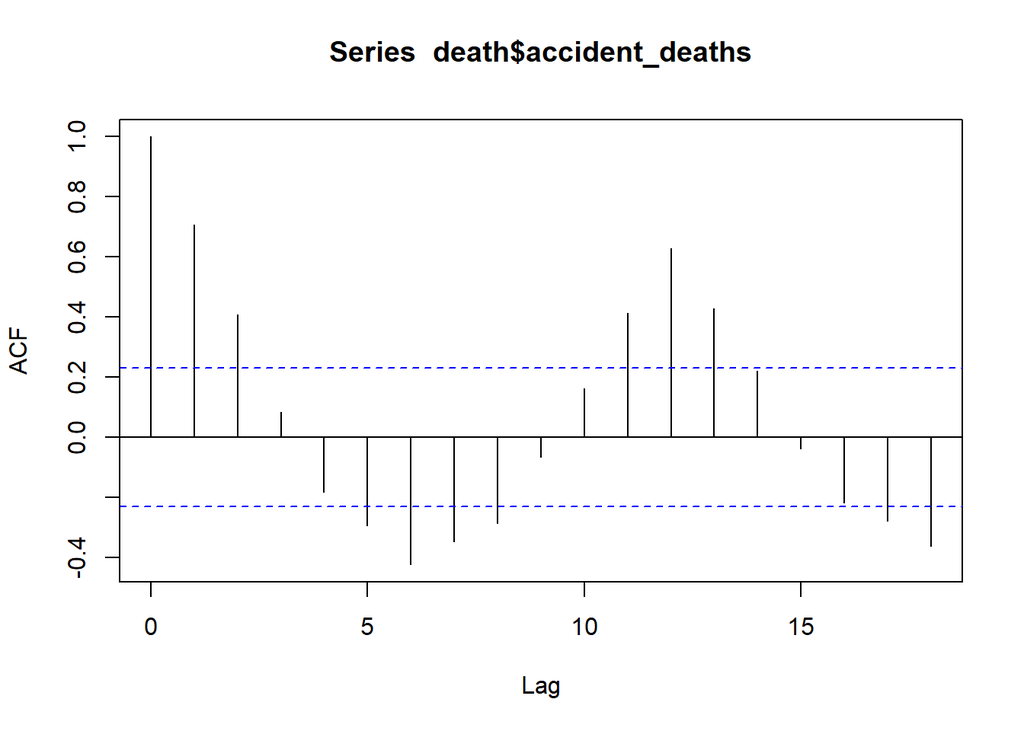

```r
acf(death$accident_deaths)
```

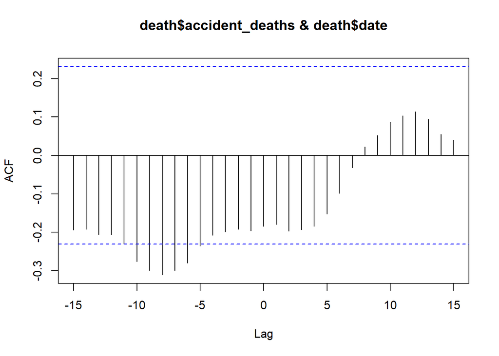

```r
ccf(death$accident_deaths, death$date)
```

- We see that we have several significant correlations here in the autocorrelation plot, more significant high value than low, and in the cross correlation plot we see that we have many spikes of low correlations.
- Transform the data to time series data

```r
death.ts <- ts(death[,-1], frequency = 12, start=c(1973, 1, 1))
death.ts
```

```
##        Jan   Feb   Mar   Apr   May   Jun   Jul   Aug   Sep   Oct   Nov   Dec
## 1973  9007  8106  8928  9137 10017 10826 11317 10744  9713  9938  9161  8927
## 1974  7750  6981  8038  8422  8714  9512 10120  9823  8743  9129  8710  8680
## 1975  8162  7306  8124  7870  9387  9556 10093  9620  8285  8466  8160  8034
## 1976  7717  7461  7767  7925  8623  8945 10078  9179  8037  8488  7874  8647
## 1977  7792  6957  7726  8106  8890  9299 10625  9302  8314  8850  8265  8796
## 1978  7836  6892  7791  8192  9115  9434 10484  9827  9110  9070  8633  9240
```

- Now we look at some distribution plots to look at the times series data

```r
plt_death <- data.frame(accident_deaths=as.matrix(death.ts),
                        month=time(death.ts))

plt_death <- plt_death %>% mutate(year = as.integer(month),
                            month = round (( month * 12) %% 12) + 1)
summary_month <- plt_death %>% group_by(month) %>% summarize(
  mean_accident_deaths = mean(accident_deaths), sd_accident_deaths = sd(
    accident_deaths))

summary_year <- plt_death %>% group_by(month) %>%
  summarize( mean_accident_deaths = mean(accident_deaths), sd_accident_deaths = sd(
  accident_deaths))
```

- The first plot is a density plot, that show the mean and median, and we se that the data is normally distributed, as we mentioned before just looking at the mean and median value.

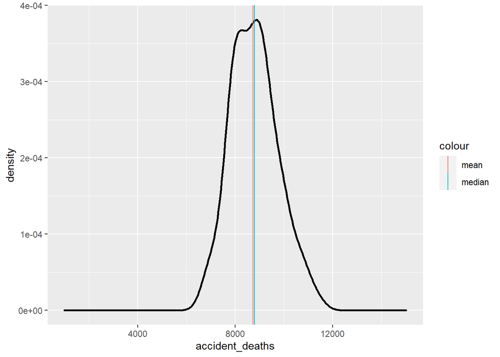

```r
p <- ggplot(plt_death, aes(x =
   accident_deaths)) +
  geom_density(size = 1) +
  geom_vline(aes(xintercept =
                   mean(accident_deaths), color
                 = "red"), size = 0.5) +
  geom_vline(aes(xintercept =
                   median(accident_deaths),
                 color = "blue"), size =
               0.5) +
  scale_color_discrete(labels
                       = c("mean", "median")) + xlim(1000, 15000)
p
```

- Box plot showing deaths per month

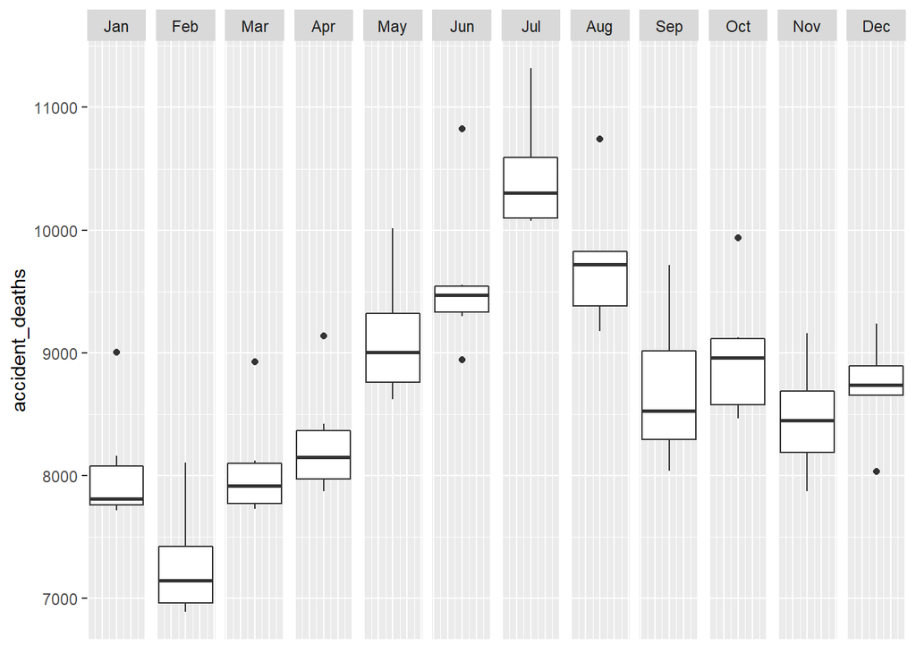

```r
m <- month.abb
names(m) <- 1:12

p <- ggplot(plt_death, aes(y =
                             accident_deaths)) +
   geom_boxplot() +
  facet_grid(.~month, labeller
             = as_labeller(m)) +
  theme(axis.text.x = element_blank(),
        axis.ticks.x = element_blank())
p
```

- Here we see that, the death rate is higher in the summer months. june, july and august, with july as the highest.
- box plot showing death per year

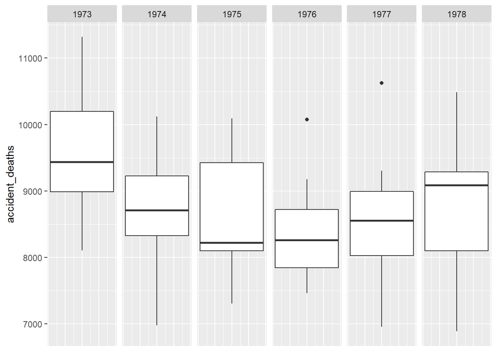

```r
p <- ggplot(plt_death, aes(y =  accident_deaths)) +
  geom_boxplot() +
  facet_grid(.~year) +
  theme(axis.text.x = element_blank(),
axis.ticks.x = element_blank())
p
```

- Again we see that 1973 have the highest death rates, and 1974 and 1978 have a high spread. and 1975 have the lowest median.
- Line plot for seasonality

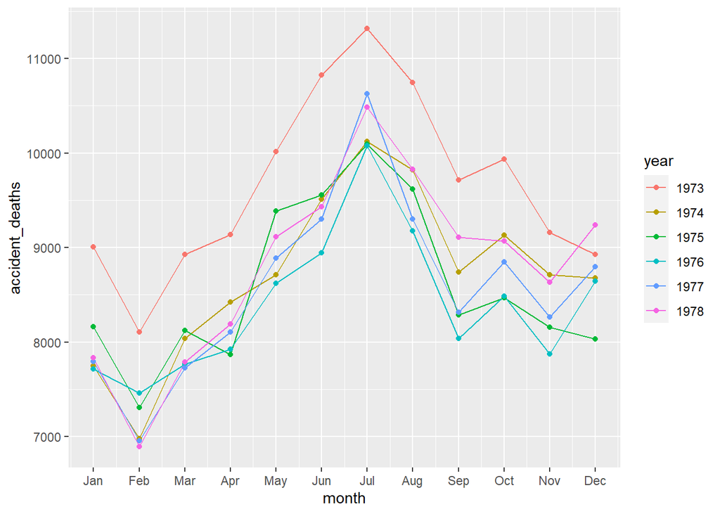

```r
p <- ggplot(plt_death, aes(x =

  month , y = accident_deaths ,
  color = as.factor(year)))+
  geom_line() +
  geom_point() +
    scale_x_continuous(labels =
    month.abb, breaks =
  1:12) +
    scale_color_discrete() +
    labs(color = "year")

p
```